# Seminar 3

Martin Søyland

# Disposition

1. Structure and expectations
2. Installing and loading packages
3. Burnside & Dollar (2000)
4. Load data
5. Replication (initial)
6. Identifying problems
7. Fix problems
8. Are we there yet?
9. OLS Diagnostics
10. Interpretation of interaction

# Structure and expectations

## Group 1

| Date | Time | Activity | Place |
| --- | --- | --- | --- |
| Mo. 13. Nov. | 14:15–16:00 | Seminar 1 | HH Seminarrom 201 |
| Mo. 20. Nov. | 14:15–16:00 | Seminar 1 | HH Seminarrom 201 |
| Mo. 27. Nov. | 14:15–16:00 | Seminar 1 | HH Seminarrom 201 |
| Mo. 4. Dec. | 14:15–16:00 | Seminar 1 | HH Seminarrom 201 |
| Mo. 11. Dec. | 14:15–16:00 | Seminar 1 | HH Seminarrom 201 |

## Group 2

| Date | Time | Activity | Place |
| --- | --- | --- | --- |
| Mo. 13. Nov. | 12:15–14:00 | Seminar 2 | HH Seminarrom 201 |
| Mo. 20. Nov. | 12:15–14:00 | Seminar 2 | HH Seminarrom 201 |
| Mo. 27. Nov. | 12:15–14:00 | Seminar 2 | HH Seminarrom 201 |
| Mo. 4. Dec. | 12:15–14:00 | Seminar 2 | HH Seminarrom 201 |
| Mo. 11. Dec. | 12:15–14:00 | Seminar 2 | HH Seminarrom 201 |

# Expectations

1. We will use significantly less time on basics – you need to know:
   - How to load data in different formats
   - How to structure R-files in folders and keep everything tidy
   - How to install and load external packages
   - How to do basic recoding (ifelse, which, etc)
   - How to make nice graphs (plot or ggplot)
   - How to run basic regression models in R (lm, glm, lmer, etc)
2. It is important to know the basics and importance of replicating standing studies
   - See this article by [Garry King](https://gking.harvard.edu/files/replication.pdf)
3. Remember that R is hard, at first. With practice, however, it is not that bad
4. If you need repetition/introduction to the basics, look over the material from [STV4020A](https://github.com/martigso/stv4020aR)
5. The material from the seminars will be available at [github](https://github.com/martigso/stv4020b)

# Installing and loading packages

```r
library(haven) # Load STATA data
library(dplyr) # Package for easy and fast data structuring
```

```r
library(ggplot2) # Package for plotting
library(sandwich) # Package for different types of standard errors
library(stargazer) # Package for making nice tables in html or latex format
```

# Burnside & Dollar (2000)

> We find that aid has a positive impact on growth in developing countries with good fiscal, monetary, and trade policies but has little effect in the presence of poor policies.

In this seminar, we will focus on the paper by [Burnside & Dollar (2000)](http://www.jstor.org/stable/117311?seq=1#page_scan_tab_contents) and try to replicate their result. As the quote above illustrates, their main argument is that the effect of aid on economic growth is contingent on how sound the policies for a given country is. The units of analysis is country periods.

## Variable description:

| **Variable name** | **Description** |
| --- | --- |
| gdp_growth | Per-capita GDP growth |
| aid | Aid/PPP GDP |
| policy | Quality of macroeconomic policies |
| gdp_pr_capita | Initial PPP GDP per capita |
| ethnic_frac | Ethnic fractionalization |
| assasinations | Assassinations |
| sub_saharan_africa | Sub-Saharan Africa |
| fast_growing_east_asia | East Asia |
| institutional_quality | Institutional quality |
| m2_gdp_lagged | M2/GDP, lagged one period |
| period | Period indicator |

## Original model

We will focus on model 5 from the paper. The results from that model is reported as:

| **Variable** | **Estimate (Std. Error)** |
| --- | --- |
| Initial GDP | -0.60 (0.57) |
| Ethnic fractionalization | -0.42 (0.72) |
| Assasinations | -0.45 (0.26) * |
| Ethnic F. * Assassinations | 0.79 (0.44) * |
| Institutional quality | 0.69 (0.17) ** |
| M2/GDP lagged | 0.012 (0.014) |
| Sub-Saharan Africa | -1.87 (0.75) ** |
| East Asia | 1.31 (0.58) ** |
| Policy index | 0.71 (0.19) ** |
| Aid/GDP | -0.021 (0.16) |
| (Aid/GDP) * policy | 0.19 (0.07) ** |
| *Notes:* |  |
| * Significant at the 10-percent level. |  |
| ** Significant at the 5-percent level |  |

Notice anything missing here?

# Loading data (from dta)

```r
aid <- read_dta("./data/aidgrowth.dta")
head(aid, 3)
```

```
## # A tibble: 3 x 12
##   country period gdp_growth       aid     policy gdp_pr_capita ethnic_frac assasinations
##     <chr>  <dbl>      <dbl>     <dbl>      <dbl>         <dbl>       <dbl>         <dbl>
## 1     ARG      2   1.700300 0.0182389  0.6565560          5637        0.31          2.75
## 2     ARG      3   1.077615 0.0171555 -0.5792648          6168        0.31          9.75
## 3     ARG      4  -1.115285 0.0239942 -0.1356454          5849        0.31          1.00
## # ... with 4 more variables: sub_saharan_africa <dbl>, fast_growing_east_asia <dbl>,
## #   institutional_quality <dbl>, m2_gdp_lagged <dbl>
```

# Replication (initial)

We look at the original model (shown above) and give a standard R formula to the `lm()` function with the varibles shown in the table.

```r
initial_model5 <- lm(gdp_growth ~ gdp_pr_capita + ethnic_frac * assasinations +
                       institutional_quality + m2_gdp_lagged +
                       sub_saharan_africa + fast_growing_east_asia + policy * aid,
                     data = aid)
summary(initial_model5)
```

```
##
## Call:
## lm(formula = gdp_growth ~ gdp_pr_capita + ethnic_frac * assasinations +
##     institutional_quality + m2_gdp_lagged + sub_saharan_africa +
##     fast_growing_east_asia + policy * aid, data = aid)
##
## Residuals:
##      Min       1Q   Median       3Q      Max
## -12.1538  -1.5874   0.0386   1.5829  13.6089
##
## Coefficients:
##                             Estimate Std. Error t value Pr(>|t|)
## (Intercept)               -1.0410219  0.9747372  -1.068  0.28652
## gdp_pr_capita             -0.0003812  0.0001368  -2.786  0.00574 **
## ethnic_frac               -0.4433386  0.8564135  -0.518  0.60513
## assasinations             -0.4570900  0.3181723  -1.437  0.15204
## institutional_quality      0.7537407  0.1858934   4.055 6.65e-05 ***
## m2_gdp_lagged             -0.0137827  0.0162300  -0.849  0.39655
## sub_saharan_africa        -1.9458082  0.7089091  -2.745  0.00648 **
## fast_growing_east_asia     1.1109101  0.7742178   1.435  0.15253
## policy                     0.7251472  0.2465391   2.941  0.00357 **
## aid                       -0.1492503  0.1808464  -0.825  0.40997
## ethnic_frac:assasinations  0.6781451  0.6604810   1.027  0.30550
## policy:aid                 0.1563717  0.1064776   1.469  0.14316
## ---
## Signif. codes:  0 '***' 0.001 '**' 0.01 '*' 0.05 '.' 0.1 ' ' 1
##
## Residual standard error: 3.07 on 258 degrees of freedom
##   (61 observations deleted due to missingness)
## Multiple R-squared:  0.2947, Adjusted R-squared:  0.2647
## F-statistic: 9.802 on 11 and 258 DF,  p-value: 8.051e-15
```

# Identifying problems

The results are not the same, which means we have missed something by looking just at the table. Reading the paper, I identified five problems with our initial replication:

1. “[…] *y<sub>it</sub>* is the logarithm of initial real per capita GDP […]”
- No indication of logging in the table
2. “[…] *a<sub>t</sub>* are fixed-time effect […]”
- FE not shown in the regression table
3. “[…] we include regional dummy variables for sub-Saharan Africa and East Asia […]”
- The variable takes the wrong class after loading the data
4. The intercept is not printet!
5. “[…] we use heteroskedasticity-consistent standard errors of the type proposed by Halbert White […]”
- This is one

# Fix problems

## Logging variables

The tables in the article do not report that GDP per capita is log transformed. However, this is stated in the data section of the paper. If we hope to replicate the results, we will have to log transform the varible ourself. To illustrate what happens with the variable when we log it, I also include a plot between the old (not logged) and new (logged) variable.

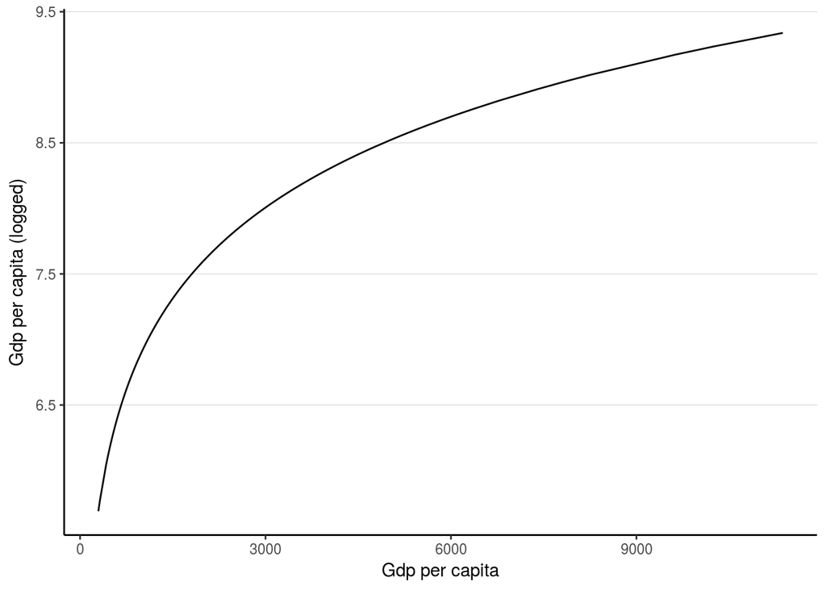

```r
aid$gdp_pr_capita_log <- log(aid$gdp_pr_capita)

ggplot(aid, aes(x = gdp_pr_capita, y = gdp_pr_capita_log)) +
  geom_line() + theme_classic() +
  labs(x = "Gdp per capita", y = "Gdp per capita (logged)") +
  theme(panel.grid.major.y = element_line(color = "gray 90"))
```

In short, we now assume that it is more important to increase GDP per capita when you already have low GDP per capita than when you already have high GDP per capita.

## Recode regions

Recoding can be done in a myriad of ways. Here, we fix the regional dummies by putting them into *one* variable and putting “Other” as the reference category. The recoding is parsed with the `mutate()` function from the *dplyr* package. Notice that the syntax is very different here. “%>%” is a pipe; it tells R that we are going to use the preceeding code, but that we are not finished yet.

```r
table(aid$fast_growing_east_asia, useNA = "always")
```

```
##
##    0    1 <NA>
##  301   30    0
```

```r
table(aid$sub_saharan_africa, useNA = "always")
```

```
##
##    0    1 <NA>
##  207  124    0
```

```r
aid <- aid %>%
  mutate(regions = ifelse(sub_saharan_africa == 1, "Sub-Saharan Africa",
                          ifelse(fast_growing_east_asia == 1, "East Asia", "Other")))

table(aid$regions, aid$fast_growing_east_asia, useNA = "always")
```

```
##
##                        0   1 <NA>
##   East Asia            0  30    0
##   Other              177   0    0
##   Sub-Saharan Africa 124   0    0
##   <NA>                 0   0    0
```

```r
table(aid$regions, aid$sub_saharan_africa, useNA = "always")
```

```
##
##                        0   1 <NA>
##   East Asia           30   0    0
##   Other              177   0    0
##   Sub-Saharan Africa   0 124    0
##   <NA>                 0   0    0
```

```r
aid$regions <- factor(aid$regions, levels = c("Other", "Sub-Saharan Africa", "East Asia"))
summary(aid$regions)
```

```
##              Other Sub-Saharan Africa          East Asia
##                177                124                 30
```

# Are we there yet?

After fixing the problems that would bias our *coefficients*, we can run the model again and compare to the original model.

```r
model5 <- lm(gdp_growth ~ gdp_pr_capita_log + ethnic_frac * assasinations +
               institutional_quality + m2_gdp_lagged + regions + policy * aid +
               factor(period),
             data = aid, na.action = "na.exclude", x = TRUE)
summary(model5)
```

```
##
## Call:
## lm(formula = gdp_growth ~ gdp_pr_capita_log + ethnic_frac * assasinations +
##     institutional_quality + m2_gdp_lagged + regions + policy *
##     aid + factor(period), data = aid, na.action = "na.exclude",
##     x = TRUE)
##
## Residuals:
##      Min       1Q   Median       3Q      Max
## -10.7213  -1.6078  -0.1369   1.5895  12.0507
##
## Coefficients:
##                           Estimate Std. Error t value Pr(>|t|)
## (Intercept)                3.39109    2.94549   1.151 0.250702
## gdp_pr_capita_log         -0.59961    0.39262  -1.527 0.127965
## ethnic_frac               -0.42359    0.81009  -0.523 0.601507
## assasinations             -0.44895    0.30119  -1.491 0.137311
## institutional_quality      0.68684    0.17452   3.936 0.000107 ***
## m2_gdp_lagged              0.01222    0.01627   0.751 0.453130
## regionsSub-Saharan Africa -1.87248    0.68095  -2.750 0.006393 **
## regionsEast Asia           1.30739    0.73063   1.789 0.074747 .
## policy                     0.71245    0.24359   2.925 0.003760 **
## aid                       -0.02078    0.17808  -0.117 0.907182
## factor(period)3           -0.01252    0.61994  -0.020 0.983901
## factor(period)4           -1.41449    0.62920  -2.248 0.025434 *
## factor(period)5           -3.46987    0.64085  -5.415 1.43e-07 ***
## factor(period)6           -2.01030    0.66149  -3.039 0.002622 **
## factor(period)7           -2.25625    0.70848  -3.185 0.001631 **
## ethnic_frac:assasinations  0.79154    0.62031   1.276 0.203111
## policy:aid                 0.18622    0.10113   1.841 0.066752 .
## ---
## Signif. codes:  0 '***' 0.001 '**' 0.01 '*' 0.05 '.' 0.1 ' ' 1
##
## Residual standard error: 2.873 on 253 degrees of freedom
##   (61 observations deleted due to missingness)
## Multiple R-squared:  0.3944, Adjusted R-squared:  0.3561
## F-statistic:  10.3 on 16 and 253 DF,  p-value: < 2.2e-16
```

The estimates are now correct. But, we still have incorrect uncertainty around our estimates compared to the original results. Burnside & Dollar state in their paper that they have used **heteroskedasticity-consistent standard errors**. Remember from the lecture that the square root of the diagonal in the covariance matrix give us the standard errors. We can utilize this knowledge with the `vcov()` function:

# Adjusting standard errors

```r
# Standard errors from summary
summary(model5)$coefficients[, "Std. Error"]
```

```
##               (Intercept)         gdp_pr_capita_log               ethnic_frac
##                2.94548915                0.39262497                0.81008937
##             assasinations     institutional_quality             m2_gdp_lagged
##                0.30118773                0.17452104                0.01626819
## regionsSub-Saharan Africa          regionsEast Asia                    policy
##                0.68095045                0.73063342                0.24359037
##                       aid           factor(period)3           factor(period)4
##                0.17807845                0.61994460                0.62920352
##           factor(period)5           factor(period)6           factor(period)7
##                0.64084750                0.66148555                0.70847987
## ethnic_frac:assasinations                policy:aid
##                0.62031024                0.10113426
```

```r
# Standard errors from covariance matrix
sqrt(diag(vcov(model5)))
```

```
##               (Intercept)         gdp_pr_capita_log               ethnic_frac
##                2.94548915                0.39262497                0.81008937
##             assasinations     institutional_quality             m2_gdp_lagged
##                0.30118773                0.17452104                0.01626819
## regionsSub-Saharan Africa          regionsEast Asia                    policy
##                0.68095045                0.73063342                0.24359037
##                       aid           factor(period)3           factor(period)4
##                0.17807845                0.61994460                0.62920352
##           factor(period)5           factor(period)6           factor(period)7
##                0.64084750                0.66148555                0.70847987
## ethnic_frac:assasinations                policy:aid
##                0.62031024                0.10113426
```

```r
# Side by side
cbind(summary(model5)$coefficients[, "Std. Error"],
      sqrt(diag(vcov(model5))))
```

```
##                                 [,1]       [,2]
## (Intercept)               2.94548915 2.94548915
## gdp_pr_capita_log         0.39262497 0.39262497
## ethnic_frac               0.81008937 0.81008937
## assasinations             0.30118773 0.30118773
## institutional_quality     0.17452104 0.17452104
## m2_gdp_lagged             0.01626819 0.01626819
## regionsSub-Saharan Africa 0.68095045 0.68095045
## regionsEast Asia          0.73063342 0.73063342
## policy                    0.24359037 0.24359037
## aid                       0.17807845 0.17807845
## factor(period)3           0.61994460 0.61994460
## factor(period)4           0.62920352 0.62920352
## factor(period)5           0.64084750 0.64084750
## factor(period)6           0.66148555 0.66148555
## factor(period)7           0.70847987 0.70847987
## ethnic_frac:assasinations 0.62031024 0.62031024
## policy:aid                0.10113426 0.10113426
```

Furthermore, the *sandwich* package can give us the corrected standard errors.

```r
vanilla_std_err <- round(sqrt(diag(vcov(model5))), digits = 2)
het_std_err <- round(sqrt(diag(vcovHC(model5, type = "HC"))), digits = 2)
original_model_std_err <- c("--", 0.57, 0.72, 0.26, 0.17, 0.01, 0.75, 0.58, 0.19, "--", "--", "--", "--", "--", "--", 0.44, 0.07)

cbind(vanilla_std_err, het_std_err, original_model_std_err)
```

```
##                           vanilla_std_err het_std_err original_model_std_err
## (Intercept)               "2.95"          "4.11"      "--"
## gdp_pr_capita_log         "0.39"          "0.57"      "0.57"
## ethnic_frac               "0.81"          "0.72"      "0.72"
## assasinations             "0.3"           "0.26"      "0.26"
## institutional_quality     "0.17"          "0.17"      "0.17"
## m2_gdp_lagged             "0.02"          "0.01"      "0.01"
## regionsSub-Saharan Africa "0.68"          "0.75"      "0.75"
## regionsEast Asia          "0.73"          "0.58"      "0.58"
## policy                    "0.24"          "0.19"      "0.19"
## aid                       "0.18"          "0.16"      "--"
## factor(period)3           "0.62"          "0.57"      "--"
## factor(period)4           "0.63"          "0.63"      "--"
## factor(period)5           "0.64"          "0.59"      "--"
## factor(period)6           "0.66"          "0.53"      "--"
## factor(period)7           "0.71"          "0.64"      "--"
## ethnic_frac:assasinations "0.62"          "0.44"      "0.44"
## policy:aid                "0.1"           "0.07"      "0.07"
```

The question on how to make this into a nice table remains. The stargazer package works pretty well for most (not all) regression models. Note that we never changed the standard errors in the regression itself. We can, instead, use the `se =` argument in stargazer to change the standard errors for the models:

```r
stargazer(initial_model5, model5, model5,
          type = "html", column.labels = c("First try", "Second try", "Hurray!"),
          dep.var.caption   = c("GDP growth"), dep.var.labels.include = FALSE,
          se = list(sqrt(diag(vcov(initial_model5))), sqrt(diag(vcov(model5))),
                    sqrt(diag(vcovHC(model5, type = "HC")))),
          keep.stat = c("n", "rsq", "adj.rsq", "aic"),
          covariate.labels = c("Intercept", "GDP per capita", "GDP per capita (logged)",
                               "Ethnic fractionalization","Assasinations", "Institutional quality",
                               "M2/GDP lagged", "Sub-Saharan Africa", "East Asia",
                               "Sub-Saharan Africa", "East Asia", "Policy index", "Aid/GDP",
                               "Ethic f. * Assasinations", "Aid/GDP * policy",
                               "Period (3)", "Period (4)", "Period (5)", "Period (6)", "Period (7)"),
          order = c(20, 1:12, 18:19, 13:17),
          star.cutoffs = c(0.05, 0.01, 0.001))
```

|  | GDP growth |  |  |
| --- | --- | --- | --- |
|  | First try | Second try | Hurray! |
|  | (1) | (2) | (3) |
| Intercept | -1.041 | 3.391 | 3.391 |
|  | (0.975) | (2.945) | (4.114) |
| GDP per capita | -0.0004** |  |  |
|  | (0.0001) |  |  |
| GDP per capita (logged) |  | -0.600 | -0.600 |
|  |  | (0.393) | (0.567) |
| Ethnic fractionalization | -0.443 | -0.424 | -0.424 |
|  | (0.856) | (0.810) | (0.724) |
| Assasinations | -0.457 | -0.449 | -0.449 |
|  | (0.318) | (0.301) | (0.259) |
| Institutional quality | 0.754*** | 0.687*** | 0.687*** |
|  | (0.186) | (0.175) | (0.171) |
| M2/GDP lagged | -0.014 | 0.012 | 0.012 |
|  | (0.016) | (0.016) | (0.014) |
| Sub-Saharan Africa | -1.946** |  |  |
|  | (0.709) |  |  |
| East Asia | 1.111 |  |  |
|  | (0.774) |  |  |
| Sub-Saharan Africa |  | -1.872** | -1.872* |
|  |  | (0.681) | (0.752) |
| East Asia |  | 1.307 | 1.307* |
|  |  | (0.731) | (0.577) |
| Policy index | 0.725** | 0.712** | 0.712*** |
|  | (0.247) | (0.244) | (0.190) |
| Aid/GDP | -0.149 | -0.021 | -0.021 |
|  | (0.181) | (0.178) | (0.159) |
| Ethic f. * Assasinations | 0.678 | 0.792 | 0.792 |
|  | (0.660) | (0.620) | (0.440) |
| Aid/GDP * policy | 0.156 | 0.186 | 0.186** |
|  | (0.106) | (0.101) | (0.069) |
| Period (3) |  | -0.013 | -0.013 |
|  |  | (0.620) | (0.573) |
| Period (4) |  | -1.414* | -1.414* |
|  |  | (0.629) | (0.633) |
| Period (5) |  | -3.470*** | -3.470*** |
|  |  | (0.641) | (0.586) |
| Period (6) |  | -2.010** | -2.010*** |
|  |  | (0.661) | (0.526) |
| Period (7) |  | -2.256** | -2.256*** |
|  |  | (0.708) | (0.635) |
| Observations | 270 | 270 | 270 |
| R<sup>2</sup> | 0.295 | 0.394 | 0.394 |
| Adjusted R<sup>2</sup> | 0.265 | 0.356 | 0.356 |
| *Note:* | p<0.05; p<0.01; p<0.001 |  |  |

## PCSE (Beck and Katz)

It does not work well with our panel (it is too unbalanced), but the Beck and Katz-style PCSE:

```r
aid_nona <- aid %>%
  select(c("country", "gdp_growth", "gdp_pr_capita_log", "ethnic_frac", "assasinations",
           "institutional_quality", "m2_gdp_lagged", "regions", "policy", "aid", "period")) %>%
  na.omit() %>%
  group_by(country) %>%
  filter(length(country) == 6)


model5_nona <- lm(gdp_growth ~ gdp_pr_capita_log + ethnic_frac * assasinations +
                    institutional_quality + m2_gdp_lagged + regions + policy * aid +
                    factor(period), data = aid_nona)
summary(model5_nona)
```

```
##
## Call:
## lm(formula = gdp_growth ~ gdp_pr_capita_log + ethnic_frac * assasinations +
##     institutional_quality + m2_gdp_lagged + regions + policy *
##     aid + factor(period), data = aid_nona)
##
## Residuals:
##     Min      1Q  Median      3Q     Max
## -8.8154 -1.3407 -0.2349  1.3763 12.3693
##
## Coefficients:
##                            Estimate Std. Error t value Pr(>|t|)
## (Intercept)                9.412994   3.506707   2.684  0.00799 **
## gdp_pr_capita_log         -1.181461   0.440654  -2.681  0.00806 **
## ethnic_frac               -1.491841   1.020440  -1.462  0.14561
## assasinations             -0.383357   0.277544  -1.381  0.16903
## institutional_quality      0.611637   0.195168   3.134  0.00203 **
## m2_gdp_lagged             -0.001217   0.022601  -0.054  0.95711
## regionsSub-Saharan Africa -1.002669   0.730518  -1.373  0.17171
## regionsEast Asia           1.539195   0.669848   2.298  0.02280 *
## policy                     0.685371   0.227789   3.009  0.00302 **
## aid                       -0.220701   0.222507  -0.992  0.32267
## factor(period)3           -0.555578   0.646668  -0.859  0.39148
## factor(period)4           -1.801820   0.655184  -2.750  0.00661 **
## factor(period)5           -3.787998   0.675563  -5.607 8.23e-08 ***
## factor(period)6           -1.471003   0.694253  -2.119  0.03557 *
## factor(period)7           -1.723528   0.726822  -2.371  0.01885 *
## ethnic_frac:assasinations  0.660485   0.567430   1.164  0.24607
## policy:aid                -0.017200   0.139310  -0.123  0.90189
## ---
## Signif. codes:  0 '***' 0.001 '**' 0.01 '*' 0.05 '.' 0.1 ' ' 1
##
## Residual standard error: 2.512 on 169 degrees of freedom
## Multiple R-squared:  0.4695, Adjusted R-squared:  0.4193
## F-statistic: 9.348 on 16 and 169 DF,  p-value: 2.537e-16
```

```r
library(pcse)
model5_pcse <- pcse(model5_nona, groupN = aid_nona$country, groupT = aid_nona$period)
summary(model5_pcse)
```

```
##
##  Results:
##
##                               Estimate       PCSE      t value     Pr(>|t|)
## (Intercept)                9.412994099 5.73159252   1.64229995 1.023873e-01
## gdp_pr_capita_log         -1.181460895 0.81795513  -1.44440795 1.504757e-01
## ethnic_frac               -1.491840643 0.80585593  -1.85124981 6.587872e-02
## assasinations             -0.383356505 0.24181510  -1.58532906 1.147610e-01
## institutional_quality      0.611637059 0.16578749   3.68928352 3.029511e-04
## m2_gdp_lagged             -0.001217336 0.02249326  -0.05412005 9.569034e-01
## regionsSub-Saharan Africa -1.002669120 0.95664613  -1.04810869 2.960851e-01
## regionsEast Asia           1.539195366 0.43527484   3.53614596 5.240931e-04
## policy                     0.685371124 0.21529516   3.18340232 1.732921e-03
## aid                       -0.220700503 0.17256230  -1.27896131 2.026641e-01
## factor(period)3           -0.555577950 0.11003549  -5.04907959 1.140590e-06
## factor(period)4           -1.801819860 0.20081426  -8.97256937 5.379418e-16
## factor(period)5           -3.787997954 0.23814285 -15.90641079 2.056271e-35
## factor(period)6           -1.471003243 0.33050376  -4.45079120 1.548270e-05
## factor(period)7           -1.723527903 0.45949985  -3.75087803 2.418394e-04
## ethnic_frac:assasinations  0.660485260 0.50654023   1.30391470 1.940359e-01
## policy:aid                -0.017199614 0.11529754  -0.14917590 8.815927e-01
##
##  ---------------------------------------------
##
## # Valid Obs = 186; # Missing Obs = 0; Degrees of Freedom = 169.
```

# Robustness

Recall the robustness tests for OLS from STV4020A. We can use eye-ball tests:

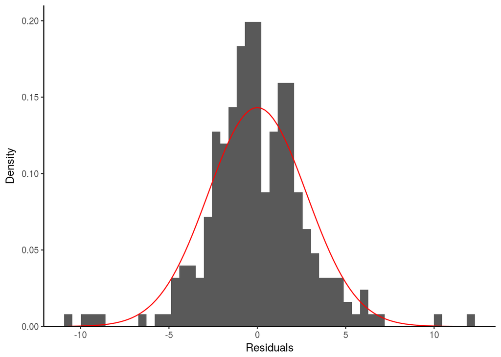

```r
# Putting residuals and fitted values into the data frame
aid$pred <- predict(model5)
aid$res <- resid(model5)

# Plotting normality of residuals
ggplot(aid, aes(x = res)) +
  geom_histogram(bins = 50, aes(y = ..density..)) +
  stat_function(fun=dnorm, color="red",
                args=list(mean=mean(aid$res, na.rm = TRUE),
                          sd=sd(aid$res, na.rm = TRUE))) +
  scale_y_continuous(limits = c(0, .21), expand = c(0,0)) +
  theme_classic() + labs(y = "Density", x = "Residuals")
```

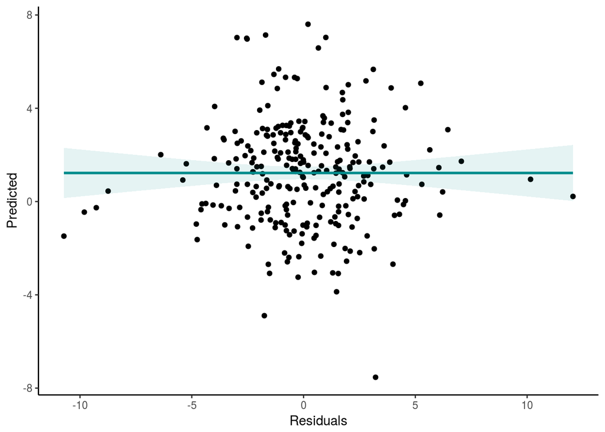

```r
# Plotting residuals vs fitted values (heteroscedasticity)
ggplot(aid, aes(x = res, y = pred)) +
  geom_point() +
  geom_smooth(method = "lm", color = "darkcyan", fill = "darkcyan", alpha = .1) +
  labs(x = "Residuals", y = "Predicted") +
  theme_classic()
```

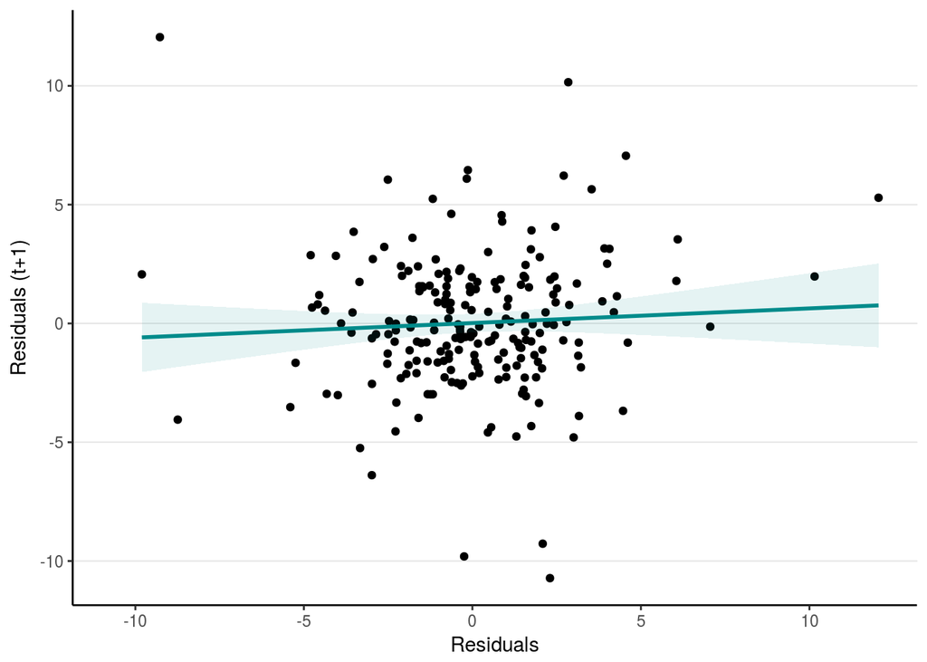

```r
# Autocorrelation
aid %>%
  arrange(country, period) %>%
  group_by(country) %>%
  select(country, period, res) %>%
  mutate(res_t1 = lag(res)) %>%
  ggplot(aes(x = res, y = res_t1)) +
  geom_point() +
  geom_smooth(method = "lm", color = "darkcyan", fill = "darkcyan", alpha = .1) +
  labs(x = "Residuals", y = "Residuals (t+1)") +
  theme_classic() +
  theme(panel.grid.major.y = element_line(color = "gray90"))
```

Or, more formal tests:

```r
# Shapiro-Wilk test of normality.
shapiro.test(aid$res)
```

```
##
##  Shapiro-Wilk normality test
##
## data:  aid$res
## W = 0.96323, p-value = 2.223e-06
```

```r
# Variance inflation factors to check for multicolinearity
car::vif(model5)
```

```
##                               GVIF Df GVIF^(1/(2*Df))
## gdp_pr_capita_log         2.487685  1        1.577240
## ethnic_frac               1.944429  1        1.394428
## assasinations             4.588600  1        2.142102
## institutional_quality     1.509069  1        1.228442
## m2_gdp_lagged             1.345847  1        1.160107
## regions                   5.006125  2        1.495807
## policy                    2.712507  1        1.646969
## aid                       3.169260  1        1.780241
## factor(period)            1.514257  5        1.042365
## ethnic_frac:assasinations 4.663442  1        2.159500
## policy:aid                2.633899  1        1.622929
```

```r
# Inspect the correlation matrix. Which variables are correlating highly?
cor_mat <- cor(model5$x[, 2:ncol(model5$x)])
cor_mat
```

```
##                           gdp_pr_capita_log ethnic_frac assasinations institutional_quality
## gdp_pr_capita_log                1.00000000 -0.46701609   0.147450588            0.33039893
## ethnic_frac                     -0.46701609  1.00000000  -0.079537031           -0.06986208
## assasinations                    0.14745059 -0.07953703   1.000000000           -0.18345510
## institutional_quality            0.33039893 -0.06986208  -0.183455100            1.00000000
## m2_gdp_lagged                    0.17778370 -0.08565734  -0.023618735            0.11011451
## regionsSub-Saharan Africa       -0.59115019  0.53627691  -0.216439061            0.05549373
## regionsEast Asia                 0.08265752  0.13137134  -0.041600145            0.18888330
## policy                           0.14128985 -0.03563012  -0.005454529            0.24774438
## aid                             -0.59797052  0.25410576  -0.132527059           -0.13223484
## factor(period)3                 -0.02543118 -0.02001804  -0.024230145           -0.01556870
## factor(period)4                  0.02226549  0.01349206   0.034887667            0.02050557
## factor(period)5                 -0.01267750  0.02733466  -0.039129592            0.01058780
## factor(period)6                 -0.02589694  0.02250421  -0.045834328           -0.01115741
## factor(period)7                  0.09012726 -0.03547421   0.128539878            0.02185944
## ethnic_frac:assasinations        0.05666723  0.10396696   0.860656203           -0.19873842
## policy:aid                      -0.24866920  0.10042680  -0.040600216            0.03342617
##                           m2_gdp_lagged regionsSub-Saharan Africa regionsEast Asia       policy
## gdp_pr_capita_log            0.17778370              -0.591150190      0.082657516  0.141289847
## ethnic_frac                 -0.08565734               0.536276907      0.131371336 -0.035630117
## assasinations               -0.02361873              -0.216439061     -0.041600145 -0.005454529
## institutional_quality        0.11011451               0.055493732      0.188883299  0.247744381
## m2_gdp_lagged                1.00000000              -0.249114710      0.125760280  0.035682893
## regionsSub-Saharan Africa   -0.24911471               1.000000000     -0.233497916 -0.179567876
## regionsEast Asia             0.12576028              -0.233497916      1.000000000  0.475568878
## policy                       0.03568289              -0.179567876      0.475568878  1.000000000
## aid                         -0.02923196               0.626207380     -0.240129793 -0.157690231
## factor(period)3             -0.12460028              -0.005821629     -0.006906908 -0.070436772
## factor(period)4             -0.06883563               0.029960446     -0.010274937 -0.058985025
## factor(period)5              0.06254627               0.029960446     -0.010274937 -0.173444714
## factor(period)6              0.19833855               0.036660527     -0.006906908  0.029099868
## factor(period)7              0.16124774              -0.042257636      0.022349508  0.282334572
## ethnic_frac:assasinations   -0.02802516              -0.166810450      0.016922127 -0.044402666
## policy:aid                  -0.09893720               0.329749347     -0.080665646  0.427799524
##                                   aid factor(period)3 factor(period)4 factor(period)5
## gdp_pr_capita_log         -0.59797052    -0.025431179      0.02226549    -0.012677504
## ethnic_frac                0.25410576    -0.020018036      0.01349206     0.027334660
## assasinations             -0.13252706    -0.024230145      0.03488767    -0.039129592
## institutional_quality     -0.13223484    -0.015568701      0.02050557     0.010587805
## m2_gdp_lagged             -0.02923196    -0.124600283     -0.06883563     0.062546268
```

[output cut: 13 more lines]

```
## ethnic_frac                   0.022504211     -0.03547421               0.103966960  0.10042680
## assasinations                -0.045834328      0.12853988               0.860656203 -0.04060022
## institutional_quality        -0.011157409      0.02185944              -0.198738416  0.03342617
## m2_gdp_lagged                 0.198338545      0.16124774              -0.028025160 -0.09893720
## regionsSub-Saharan Africa     0.036660527     -0.04225764              -0.166810450  0.32974935
## regionsEast Asia             -0.006906908      0.02234951               0.016922127 -0.08066565
## policy                        0.029099868      0.28233457              -0.044402666  0.42779952
## aid                           0.114710572      0.01245595              -0.133502137  0.53493062
## factor(period)3              -0.210762332     -0.18863523              -0.035609853 -0.10054845
## factor(period)4              -0.213471857     -0.19106030               0.039916026 -0.02841127
## factor(period)5              -0.213471857     -0.19106030              -0.007795912 -0.05547455
## factor(period)6               1.000000000     -0.18863523              -0.030393740  0.14717791
## factor(period)7              -0.188635232      1.00000000               0.054392691  0.11670416
## ethnic_frac:assasinations    -0.030393740      0.05439269               1.000000000 -0.06475844
## policy:aid                    0.147177913      0.11670416              -0.064758441  1.00000000
```

```r
apply(cor_mat, 2, function(x) ifelse(x < .25, NA, x))
```

```
##                           gdp_pr_capita_log ethnic_frac assasinations institutional_quality
## gdp_pr_capita_log                 1.0000000          NA            NA             0.3303989
## ethnic_frac                              NA   1.0000000            NA                    NA
## assasinations                            NA          NA     1.0000000                    NA
## institutional_quality             0.3303989          NA            NA             1.0000000
## m2_gdp_lagged                            NA          NA            NA                    NA
## regionsSub-Saharan Africa                NA   0.5362769            NA                    NA
## regionsEast Asia                         NA          NA            NA                    NA
## policy                                   NA          NA            NA                    NA
## aid                                      NA   0.2541058            NA                    NA
## factor(period)3                          NA          NA            NA                    NA
## factor(period)4                          NA          NA            NA                    NA
## factor(period)5                          NA          NA            NA                    NA
## factor(period)6                          NA          NA            NA                    NA
## factor(period)7                          NA          NA            NA                    NA
## ethnic_frac:assasinations                NA          NA     0.8606562                    NA
## policy:aid                               NA          NA            NA                    NA
##                           m2_gdp_lagged regionsSub-Saharan Africa regionsEast Asia    policy
## gdp_pr_capita_log                    NA                        NA               NA        NA
## ethnic_frac                          NA                 0.5362769               NA        NA
## assasinations                        NA                        NA               NA        NA
## institutional_quality                NA                        NA               NA        NA
## m2_gdp_lagged                         1                        NA               NA        NA
## regionsSub-Saharan Africa            NA                 1.0000000               NA        NA
## regionsEast Asia                     NA                        NA        1.0000000 0.4755689
## policy                               NA                        NA        0.4755689 1.0000000
## aid                                  NA                 0.6262074               NA        NA
## factor(period)3                      NA                        NA               NA        NA
## factor(period)4                      NA                        NA               NA        NA
## factor(period)5                      NA                        NA               NA        NA
## factor(period)6                      NA                        NA               NA        NA
## factor(period)7                      NA                        NA               NA 0.2823346
## ethnic_frac:assasinations            NA                        NA               NA        NA
## policy:aid                           NA                 0.3297493               NA 0.4277995
##                                 aid factor(period)3 factor(period)4 factor(period)5 factor(period)6
## gdp_pr_capita_log                NA              NA              NA              NA              NA
## ethnic_frac               0.2541058              NA              NA              NA              NA
## assasinations                    NA              NA              NA              NA              NA
## institutional_quality            NA              NA              NA              NA              NA
## m2_gdp_lagged                    NA              NA              NA              NA              NA
```

[output cut: 13 more lines]

```
## ethnic_frac                            NA                        NA         NA
## assasinations                          NA                 0.8606562         NA
## institutional_quality                  NA                        NA         NA
## m2_gdp_lagged                          NA                        NA         NA
## regionsSub-Saharan Africa              NA                        NA  0.3297493
## regionsEast Asia                       NA                        NA         NA
## policy                          0.2823346                        NA  0.4277995
## aid                                    NA                        NA  0.5349306
## factor(period)3                        NA                        NA         NA
## factor(period)4                        NA                        NA         NA
## factor(period)5                        NA                        NA         NA
## factor(period)6                        NA                        NA         NA
## factor(period)7                 1.0000000                        NA         NA
## ethnic_frac:assasinations              NA                 1.0000000         NA
## policy:aid                             NA                        NA  1.0000000
```

```r
# Breusch-Pagan test
lmtest::bptest(model5)
```

```
##
##  studentized Breusch-Pagan test
##
## data:  model5
## BP = 18.842, df = 16, p-value = 0.277
```

```r
# Durbin-Watson test
lmtest::dwtest(model5)
```

```
##
##  Durbin-Watson test
##
## data:  model5
## DW = 1.94, p-value = 0.1955
## alternative hypothesis: true autocorrelation is greater than 0
```

# Beyond Burnside & Dollar

## Fixed and random effects

```r
model_fe <- lm(gdp_growth ~ gdp_pr_capita_log + ethnic_frac * assasinations +
               institutional_quality + m2_gdp_lagged + regions + policy * aid +
                factor(country),
             data = aid, na.action = "na.exclude", x = TRUE)
head(summary(model_fe)$coefficients)
```

```
##                          Estimate  Std. Error    t value    Pr(>|t|)
## (Intercept)           26.10644529 13.67658283  1.9088427 0.057665625
## gdp_pr_capita_log     -3.56382837  1.17156401 -3.0419408 0.002654707
## ethnic_frac           -4.51983687  9.68822028 -0.4665291 0.641327415
## assasinations         -0.54247021  0.40637221 -1.3349097 0.183372200
## institutional_quality  2.04600685  2.26819338  0.9020425 0.368082673
## m2_gdp_lagged         -0.06329136  0.02734894 -2.3142160 0.021636800
```

```r
# or using plm():
library(plm)
model_fe2 <- plm(gdp_growth ~ gdp_pr_capita_log + ethnic_frac * assasinations +
               institutional_quality + m2_gdp_lagged + regions + policy * aid,
               index = c("country", "period"), model = "within", effect = "individual",
             data = aid)

summary(model_fe2)
```

```
## Oneway (individual) effect Within Model
##
## Call:
## plm(formula = gdp_growth ~ gdp_pr_capita_log + ethnic_frac *
##     assasinations + institutional_quality + m2_gdp_lagged + regions +
##     policy * aid, data = aid, effect = "individual", model = "within",
##     index = c("country", "period"))
##
## Unbalanced Panel: n=56, T=1-6, N=270
##
## Residuals :
##     Min.  1st Qu.   Median  3rd Qu.     Max.
## -10.6305  -1.4223   0.0000   1.3128  11.9712
##
## Coefficients :
##                            Estimate Std. Error t-value  Pr(>|t|)
## gdp_pr_capita_log         -3.563828   1.171564 -3.0419 0.0026547 **
## assasinations             -0.542470   0.406372 -1.3349 0.1833722
## m2_gdp_lagged             -0.063291   0.027349 -2.3142 0.0216368 *
## policy                     1.179939   0.321901  3.6655 0.0003137 ***
## aid                       -0.103853   0.284214 -0.3654 0.7151820
## ethnic_frac:assasinations  1.080480   0.843196  1.2814 0.2014836
## policy:aid                -0.141634   0.178043 -0.7955 0.4272328
## ---
## Signif. codes:  0 '***' 0.001 '**' 0.01 '*' 0.05 '.' 0.1 ' ' 1
##
## Total Sum of Squares:    2187.3
## Residual Sum of Squares: 1819.3
## R-Squared:      0.16824
## Adj. R-Squared: -0.080888
## F-statistic: 5.98134 on 7 and 207 DF, p-value: 2.3469e-06
```

```r
model_ranef <- plm(gdp_growth ~ gdp_pr_capita_log + ethnic_frac * assasinations +
                     institutional_quality + m2_gdp_lagged + regions + policy * aid,
                   index = c("country", "period"), model = "random", effect = "individual",
                   data = aid)

summary(model_ranef)
```

```
## Oneway (individual) effect Random Effect Model
##    (Swamy-Arora's transformation)
##
## Call:
## plm(formula = gdp_growth ~ gdp_pr_capita_log + ethnic_frac *
##     assasinations + institutional_quality + m2_gdp_lagged + regions +
##     policy * aid, data = aid, effect = "individual", model = "random",
##     index = c("country", "period"))
##
## Unbalanced Panel: n=56, T=1-6, N=270
##
## Effects:
##                  var std.dev share
## idiosyncratic 8.9620  2.9937 0.989
## individual    0.1031  0.3210 0.011
## theta  :
##     Min.  1st Qu.   Median     Mean  3rd Qu.     Max.
## 0.005701 0.027567 0.032812 0.029383 0.032812 0.032812
##
## Residuals :
##     Min.  1st Qu.   Median     Mean  3rd Qu.     Max.
## -12.8176  -1.6396   0.0318   0.0009   1.6008  13.6519
##
## Coefficients :
##                            Estimate Std. Error t-value  Pr(>|t|)
## (Intercept)                5.495674   3.184626  1.7257 0.0856006 .
## gdp_pr_capita_log         -0.953722   0.423572 -2.2516 0.0251882 *
## ethnic_frac               -0.561140   0.887952 -0.6319 0.5279798
## assasinations             -0.465017   0.323093 -1.4393 0.1512872
## institutional_quality      0.719181   0.190851  3.7683 0.0002037 ***
## m2_gdp_lagged             -0.014892   0.016541 -0.9003 0.3687861
## regionsSub-Saharan Africa -2.074519   0.742720 -2.7931 0.0056111 **
## regionsEast Asia           1.173901   0.794465  1.4776 0.1407347
## policy                     0.749178   0.249481  3.0029 0.0029364 **
## aid                       -0.170254   0.190527 -0.8936 0.3723705
## ethnic_frac:assasinations  0.716352   0.669558  1.0699 0.2856700
## policy:aid                 0.163236   0.108430  1.5054 0.1334330
## ---
## Signif. codes:  0 '***' 0.001 '**' 0.01 '*' 0.05 '.' 0.1 ' ' 1
##
## Total Sum of Squares:    3378.9
## Residual Sum of Squares: 2431.6
## R-Squared:      0.28035
## Adj. R-Squared: 0.24966
## F-statistic: 9.13689 on 11 and 258 DF, p-value: 8.7701e-14
```

```r
## We can use the Hausman test to test whether RE is unbiased:
phtest(model_fe2, model_ranef)
```

```
##
##  Hausman Test
##
## data:  gdp_growth ~ gdp_pr_capita_log + ethnic_frac * assasinations +  ...
## chisq = 25.879, df = 7, p-value = 0.0005294
## alternative hypothesis: one model is inconsistent
```

```r
## We reject the null hypothesis that the two models are similar
```